# Kevin Synagogue Panjaitan

AK281 ADW

2024-05-14

# Tujuan Praktikum

## 1. Memahami dan mengidentifikasi model deret waktu heteroskedastik;

## 2. Menganalisis data real deret waktu heteroskedastik dan memodelkannya

```r
# Untuk membaca data dengan format csv
library(rugarch)
library(readr)
# Untuk membersihkan data
library(tidyr)
```

```r
# Untuk mengubah data menjadi Time Series, membuat plot ACF,
# plot PACF, Model ARIMA dan ADF Test
library(tseries)
# Untuk melihat signifikansi koefisien dari parameter
library(lmtest)
# Untuk memprediksi data dari model
library(forecast)
# Untuk memeriksa adanya sifat keheteroskedastisan pada data
library(FinTS)
# Uji Anderson Darling
library(nortest)
# Model GARCH
library(fGarch)
```

# 1 EDA

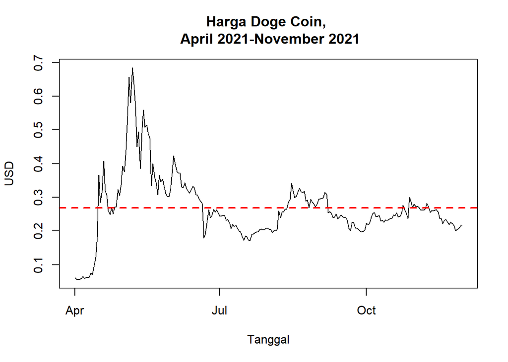

```r
# Memanggil Data
data <- read_csv("DOGE-USD.csv", col_types = cols(Date = col_date(format = "%m/%d/%Y")))
plot(data$Date, data$Close, type = "l", main = "Harga Doge Coin, \n April 2021-November 2021",
xlab = "Tanggal", ylab = "USD")
#View(data)
# Membuat garis rataan
abline(h = mean(data$Close), lwd = 2, lty = 2, col = "red")
```

# Statistik Deskriptif

```r
summary(data)
```

```
##       Date                Close
##  Min.   :2021-04-01   Min.   :0.0558
##  1st Qu.:2021-05-31   1st Qu.:0.2184
##  Median :2021-07-31   Median :0.2547
##  Mean   :2021-07-31   Mean   :0.2686
##  3rd Qu.:2021-09-30   3rd Qu.:0.3066
##  Max.   :2021-11-30   Max.   :0.6848
```

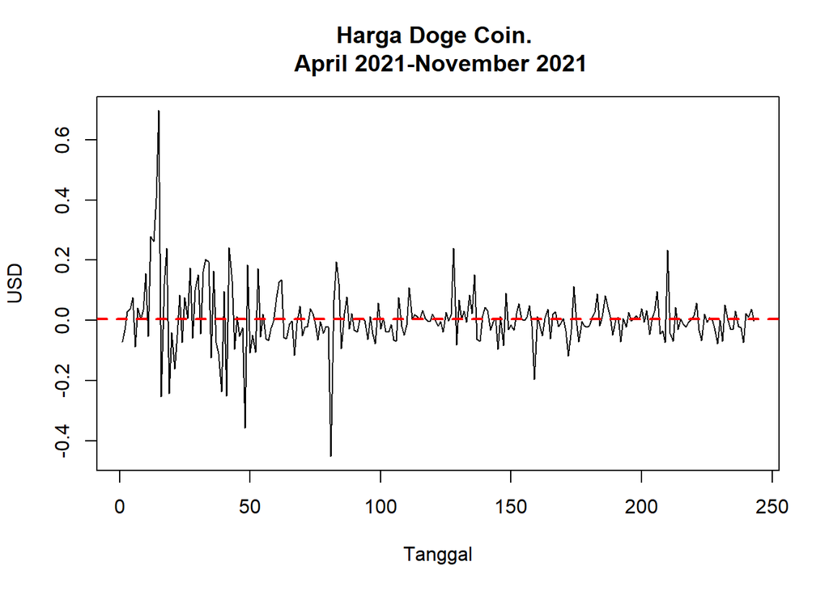

```r
ts_data <- ts(diff(log(data$Close)))
plot(ts_data, type = "l", main = "Harga Doge Coin. \n April 2021-November 2021",
xlab = "Tanggal", ylab = "USD")
abline(h = mean(ts_data), lwd = 2, lty = 2, col = "red")
```

```r
# Statistik Deskriptif
summary(ts_data)
```

```
##       Min.    1st Qu.     Median       Mean    3rd Qu.       Max.
## -0.4523407 -0.0391006 -0.0009946  0.0051128  0.0305130  0.6971347
```

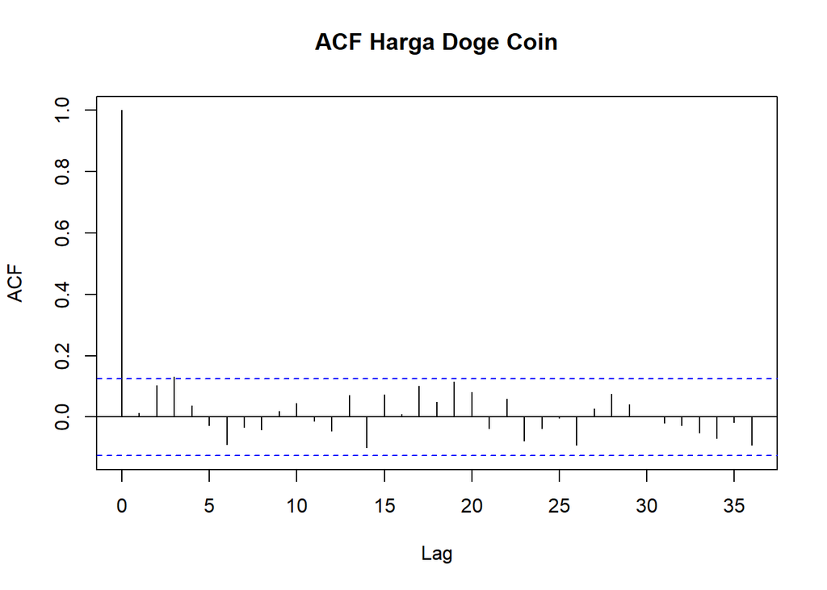

```r
acf(ts_data, main = "ACF Harga Doge Coin", lag.max = 36)
```

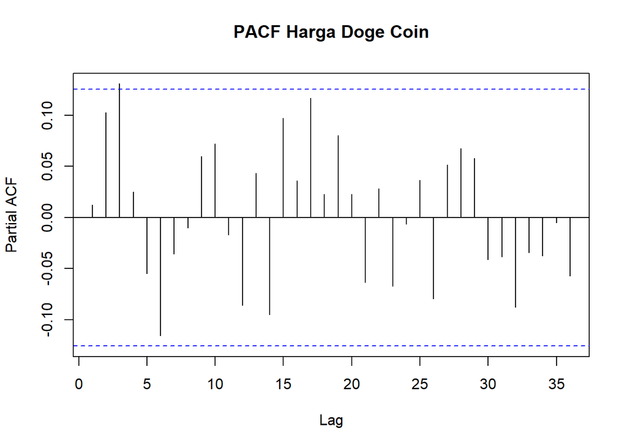

```r
pacf(ts_data, main = "PACF Harga Doge Coin", lag.max = 36)
```

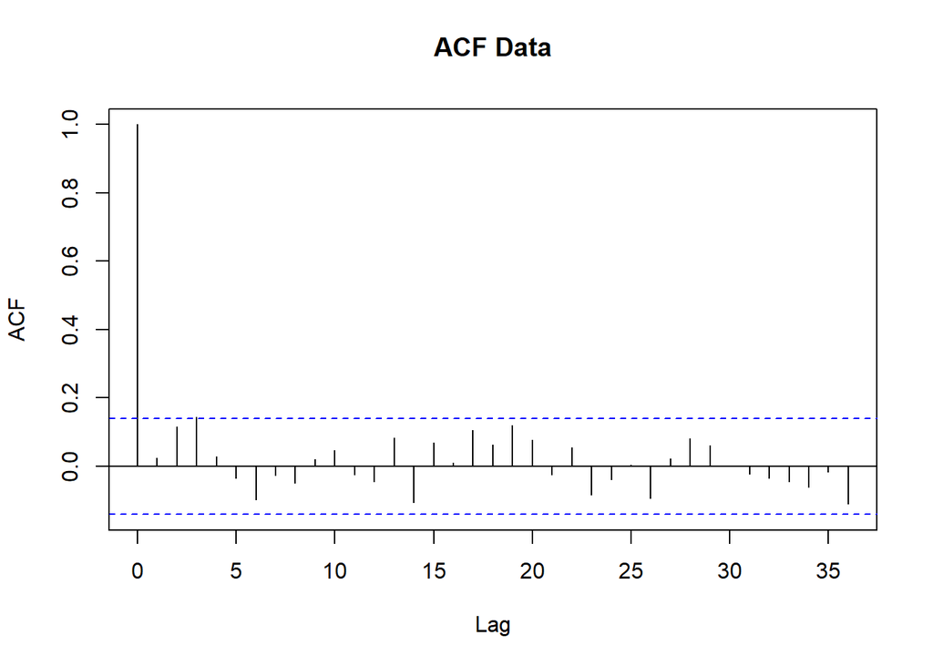

```r
ts_train <- ts_data[1:(floor(0.8 * length(ts_data)))]
ts_validation <- ts_data[ceiling(0.8 * length(ts_data)):length(ts_data)]
acf(ts_train, main = "ACF Data", lag.max = 36)
```

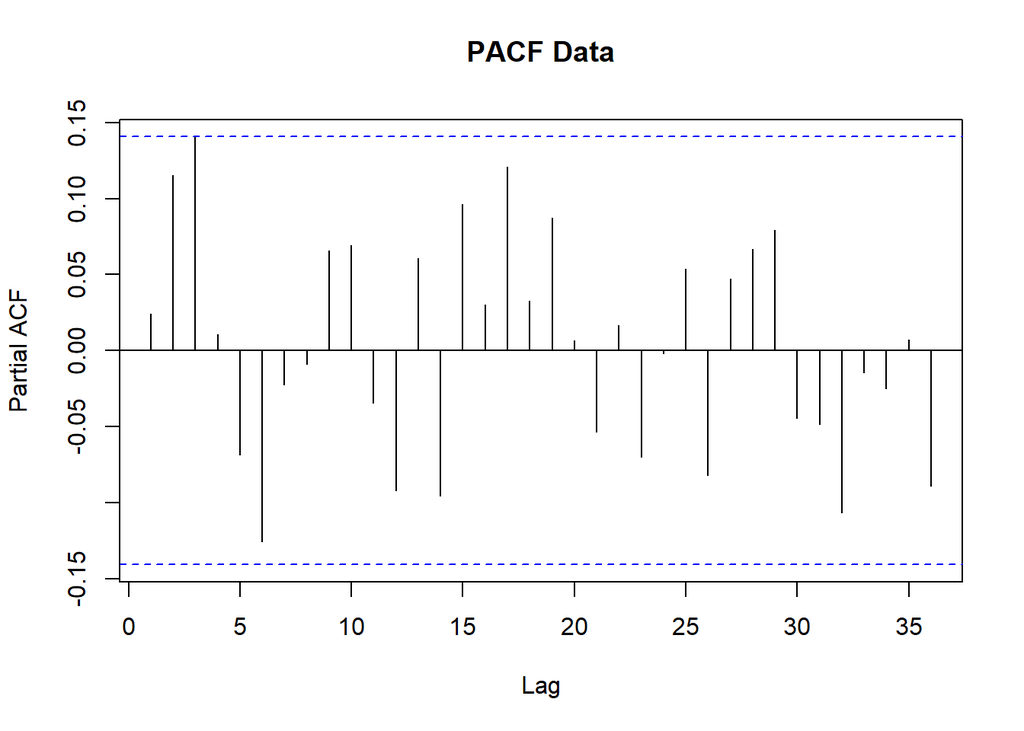

```r
pacf(ts_train, main = "PACF Data", lag.max = 36)
```

# Lakukan Forecasting

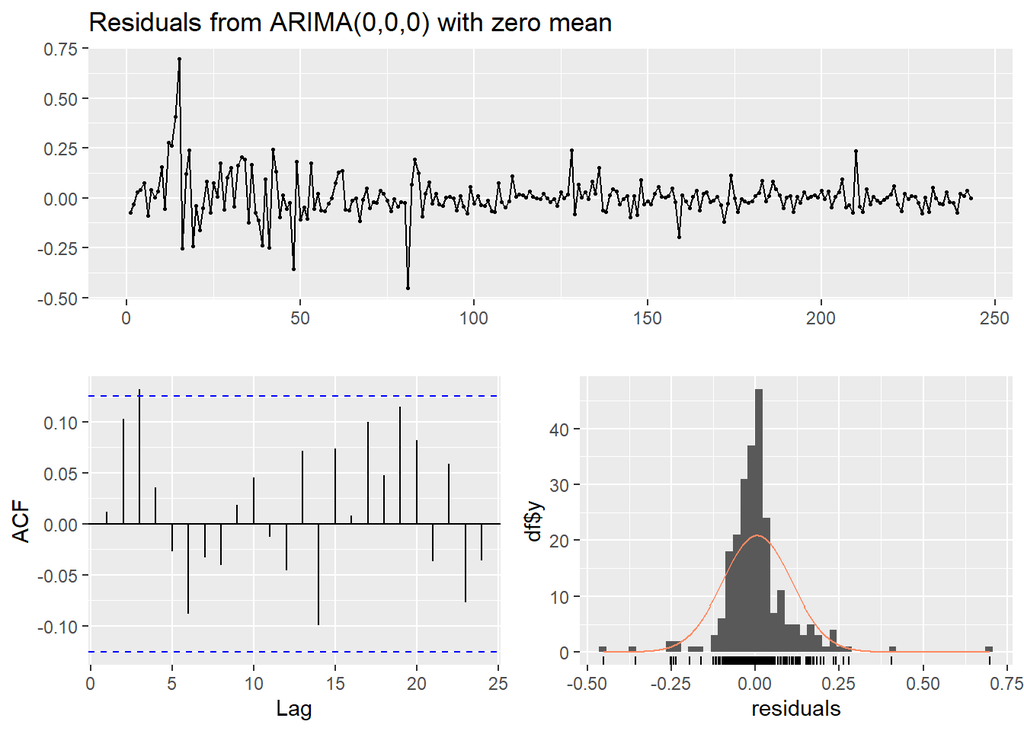

```
##
##  Ljung-Box test
##
## data:  Residuals from ARIMA(0,0,0) with zero mean
## Q* = 10.735, df = 10, p-value = 0.3785
##
## Model df: 0.   Total lags used: 10
```

```r
mod <- auto.arima(ts_data, max.q = 0, allowmean = TRUE, allowdrift = TRUE,
method = "ML")
fc <- forecast(ts_data, model = mod, h = 10)
checkresiduals(mod)
```

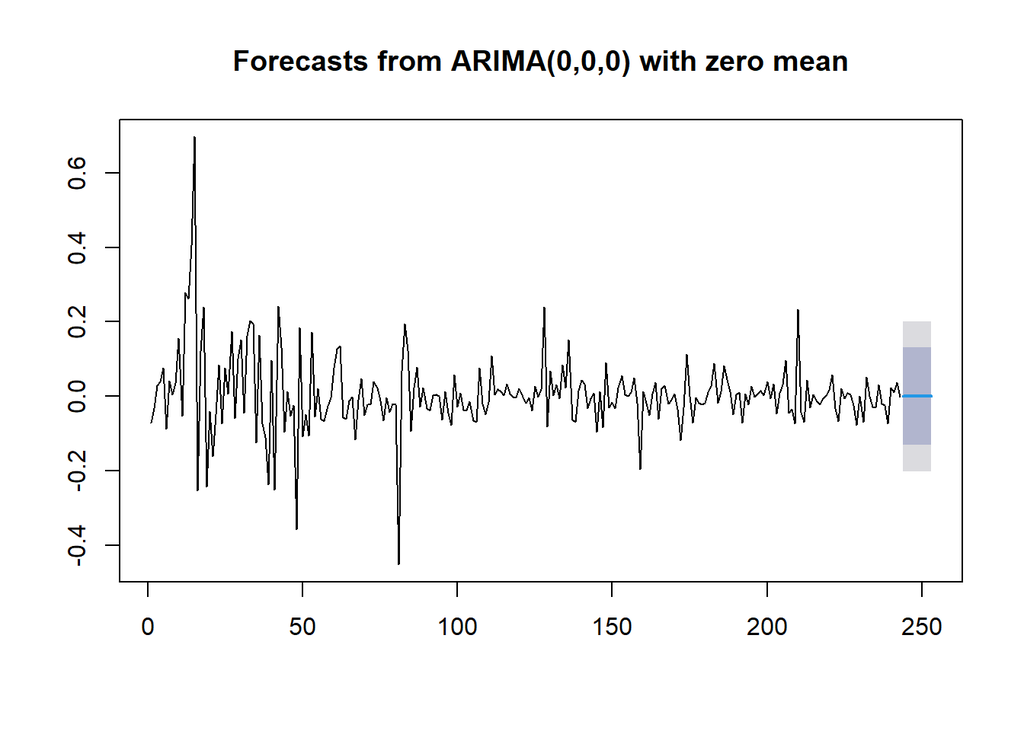

```r
plot(fc)
```

# Jurnal 1

Secara umum, penggunaan model ARIMA(0,0,0) untuk data log-return mungkin wajar dalam situasi tertentu, terutama jika data sangat stasioner dan tidak menunjukkan pola temporal yang signifikan. Namun, dalam kebanyakan kasus, model yang lebih kompleks seperti ARIMA(p,d,q) dengan p dan q yang lebih besar, atau model yang menangkap volatilitas seperti GARCH, akan memberikan representasi yang lebih akurat dan realistis terhadap sifat dan karakteristik data log-return di pasar saham dan pasar keuangan .

# Cek residuals suatu model

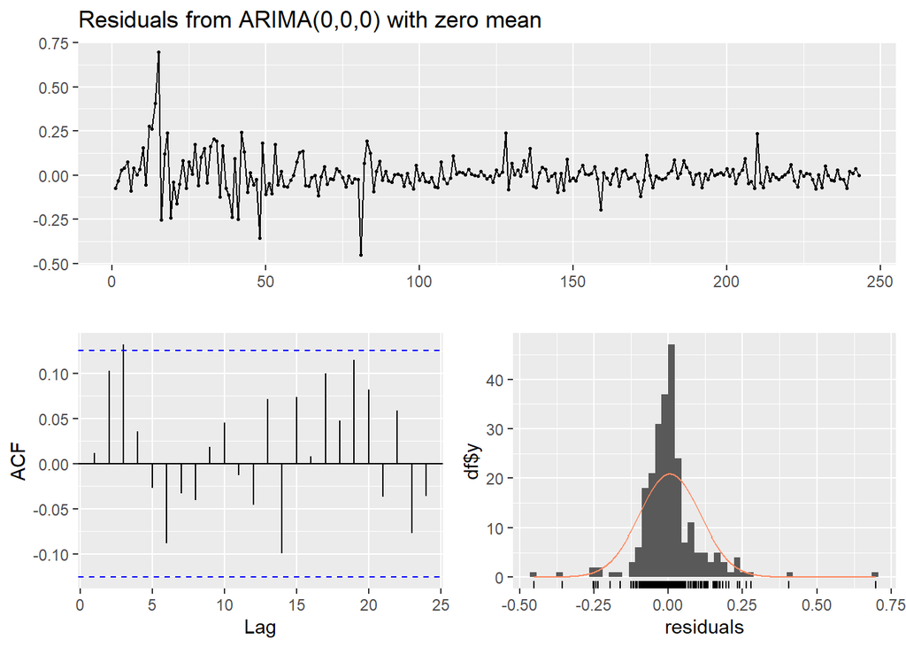

```
##
##  Ljung-Box test
##
## data:  Residuals from ARIMA(0,0,0) with zero mean
## Q* = 10.735, df = 10, p-value = 0.3785
##
## Model df: 0.   Total lags used: 10
```

```r
checkresiduals(mod)
```

# 2 Model Heteroskedastis

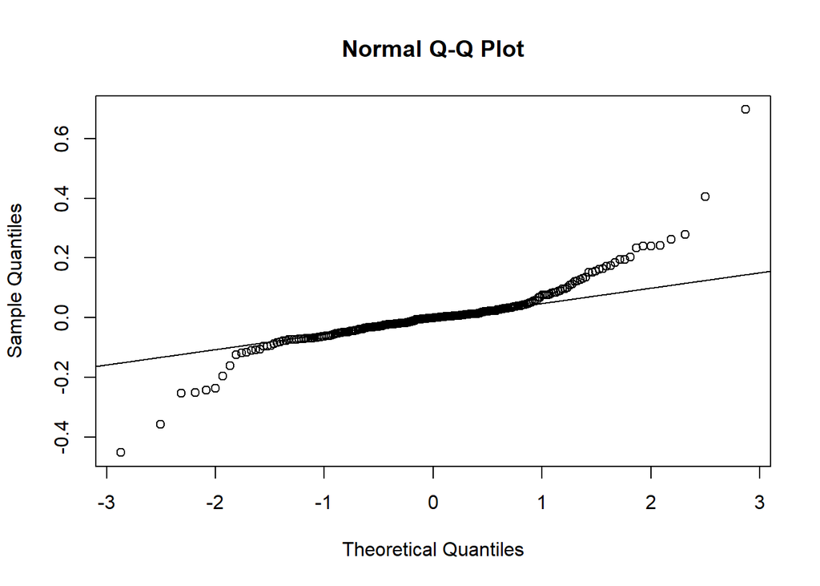

```r
residual <- residuals(mod, standardize = T)
# QQ Plot
qqnorm(residual)
qqline(residual)
```

# Uji Anderson-Darling

```r
ad.test(residual)
```

```
##
##  Anderson-Darling normality test
##
## data:  residual
## A = 10.06, p-value < 2.2e-16
```

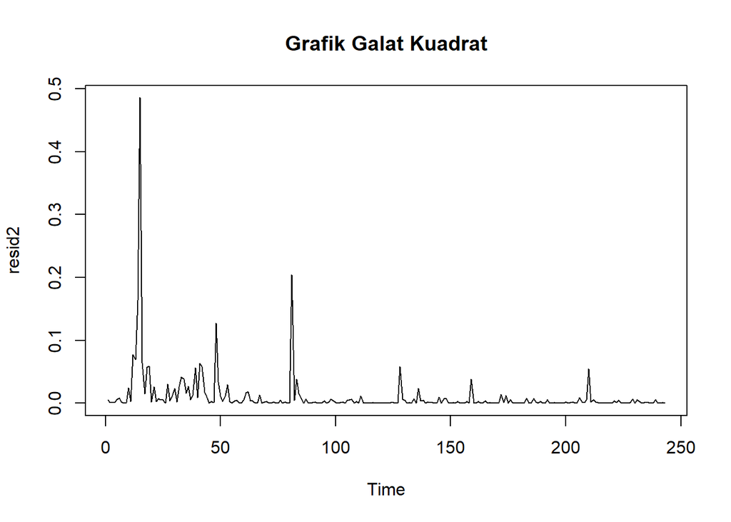

```r
resid2 <- residual^2

plot(resid2, main = "Grafik Galat Kuadrat", type = "l")
```

# Jurnal 2

## Formulasi Uji Hipotesis Box-Pierce

**Hipotesis**: - **Hipotesis Nol (H0)**: Tidak ada autokorelasi pada residual hingga lag $h$. - **Hipotesis Alternatif (H1)**: Ada autokorelasi pada residual pada setidaknya satu lag hingga lag $h$.

**Statistik Uji**:
$$Q = n \sum_{k=1}^{h} \hat{\rho}_k^2$$

- $Q$ mengikuti distribusi chi-kuadrat ($\chi^2$) dengan derajat kebebasan $h$.

## Uji Hipotesis ARCH Engle

**Hipotesis**: - **Hipotesis Nol (H0)**: Tidak ada efek ARCH (no autoregressive conditional heteroskedasticity). - **Hipotesis Alternatif (H1)**: Ada efek ARCH.

**Prosedur**: 1. **Estimasi Model Regresi**: Hitung residual ($\hat{e}_t$). 2. **Regresi Residual Kuadrat**:
$$\hat{e}_t^2 = \alpha_0 + \alpha_1 \hat{e}_{t-1}^2 + \alpha_2
\hat{e}_{t-2}^2 + \ldots + \alpha_p \hat{e}_{t-p}^2 + u_t$$
3. **Statistik Uji**:
$$\text{ARCH LM statistic} = nR^2$$

- $n$ adalah jumlah pengamatan, $R^2$ adalah koefisien determinasi dari regresi residual kuadrat.
- Statistik $nR^2$ mengikuti distribusi chi-kuadrat ($\chi^2$) dengan derajat kebebasan $p$.

```r
Box.test(resid2, lag = 100)
```

```
##
##  Box-Pierce test
##
## data:  resid2
## X-squared = 108.29, df = 100, p-value = 0.2684
```

```r
ArchTest(residual, lags = 100)
```

```
##
##  ARCH LM-test; Null hypothesis: no ARCH effects
##
## data:  residual
## Chi-squared = 94.618, df = 100, p-value = 0.6332
```

# Jurnal 3

Karena Tujuan dari Uji Box-Pierce digunakan untuk menguji keberadaan autokorelasi pada residual kuadrat yang merupakan suatu model dan Tujuan dari Uji ARCH digunakan untuk mendeteksi heteroskedastisitas bersyarat dalam residual suatu model. Heteroskedastisitas bersyarat berarti bahwa variabilitas residual dapat berubah seiring waktu, tergantung pada nilai residual sebelumnya, dan pada data ini tidak ada efek ARCH yang signifikan pada kasus ini .

# 3.Penentuan Model

Secara umum, model generalized autoregressive conditional heteroscedasticity GARCH ($p, q$) dapat ditulis dengan persamaan berikut:

$$\sigma^2_t|_{t-1} = \omega + \beta_1 \sigma^2_{t-1}|_{t-2} + \ldots +
\beta_p \sigma^2_{t-p}|_{t-p-1} + \alpha_1 r^2_{t-1} + \alpha_2
r^2_{t-2} + \ldots + \alpha_q r^2_{t-q}$$

dengan $\sigma^2_t|_{t-1}$ adalah variansi bersyarat dari data $r_t$.

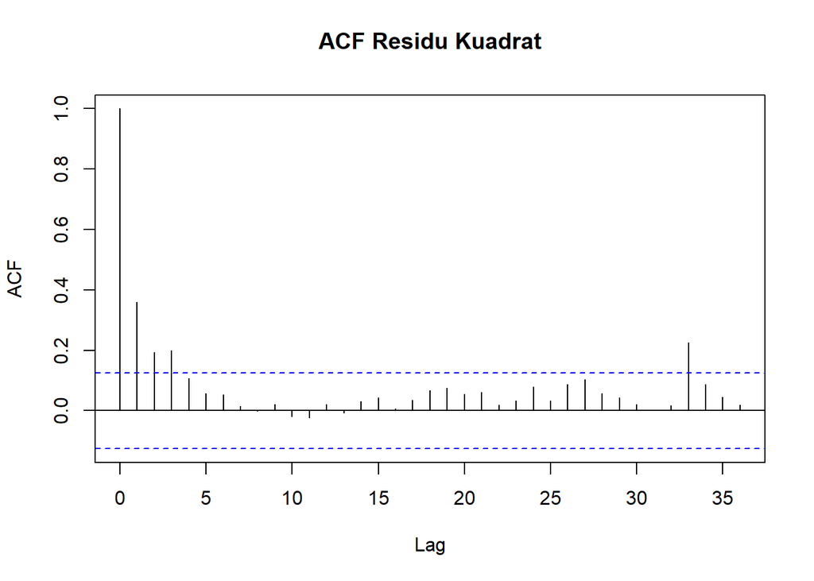

```r
acf(resid2, main = "ACF Residu Kuadrat", lag.max = 36)
```

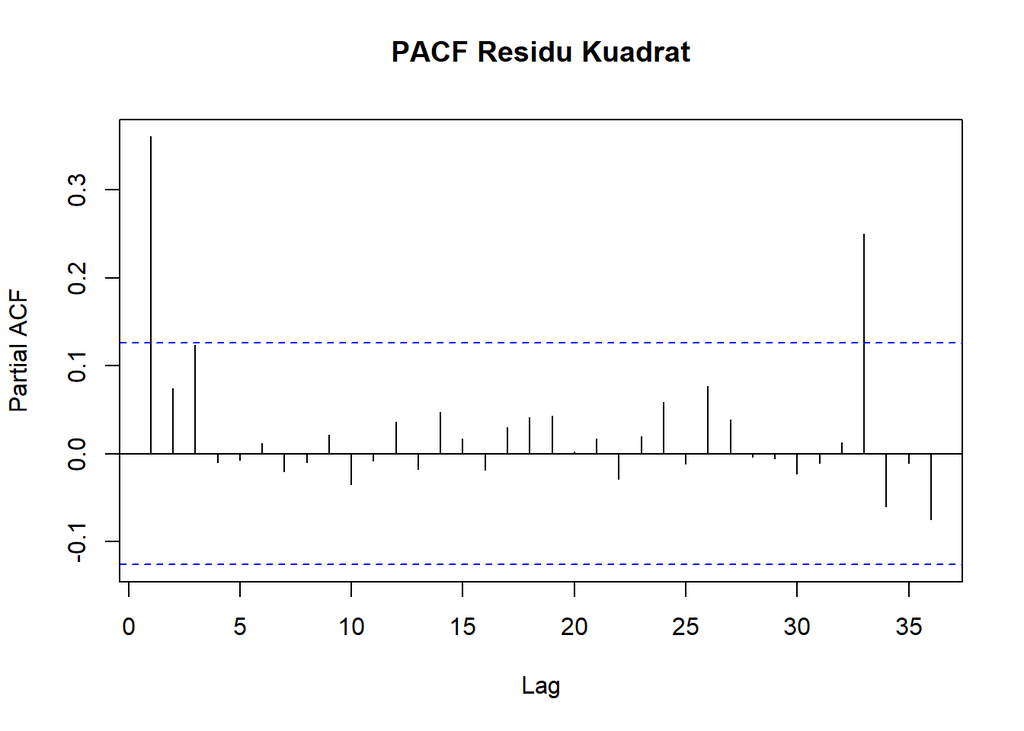

```r
pacf(resid2, main = "PACF Residu Kuadrat", lag.max = 36)
```

```r
mod_h1 <- garchFit(residual ~ garch(3, 1), data = residual, trace = F,
include.mean = F)
mod_h2 <- garchFit(residual ~ garch(3, 0), data = residual, trace = F,
include.mean = F)

mod_h3 <- garchFit(residual ~ garch(1, 1), data = residual, trace = F,
include.mean = F)


summary(mod_h2)
```

```
##
## Title:
##  GARCH Modelling
##
## Call:
##  garchFit(formula = residual ~ garch(3, 0), data = residual, include.mean = F,
##     trace = F)
##
## Mean and Variance Equation:
##  data ~ garch(3, 0)
## <environment: 0x000001c004f79bb8>
##  [data = residual]
##
## Conditional Distribution:
##  norm
##
## Coefficient(s):
##     omega     alpha1     alpha2     alpha3
## 0.0044384  0.2696736  0.2445643  0.0075717
##
## Std. Errors:
##  based on Hessian
##
## Error Analysis:
##         Estimate  Std. Error  t value Pr(>|t|)
## omega  0.0044384   0.0005636    7.876 3.33e-15 ***
## alpha1 0.2696736   0.1101893    2.447   0.0144 *
## alpha2 0.2445643   0.1234290    1.981   0.0475 *
## alpha3 0.0075717   0.0463946    0.163   0.8704
## ---
## Signif. codes:  0 '***' 0.001 '**' 0.01 '*' 0.05 '.' 0.1 ' ' 1
##
## Log Likelihood:
##  254.9702    normalized:  1.04926
##
## Description:
##  Sat May 18 07:01:41 2024 by user: Admin
##
##
## Standardised Residuals Tests:
##                                    Statistic      p-Value
##  Jarque-Bera Test   R    Chi^2  1065.8117564 0.000000e+00
##  Shapiro-Wilk Test  R    W         0.8704872 1.722955e-13
##  Ljung-Box Test     R    Q(10)     7.4559863 6.818089e-01
##  Ljung-Box Test     R    Q(15)    10.6772029 7.751233e-01
##  Ljung-Box Test     R    Q(20)    17.0262361 6.512694e-01
##  Ljung-Box Test     R^2  Q(10)     0.8969947 9.998957e-01
##  Ljung-Box Test     R^2  Q(15)     2.1165116 9.999569e-01
##  Ljung-Box Test     R^2  Q(20)     2.5747374 9.999989e-01
##  LM Arch Test       R    TR^2      1.0343492 9.999829e-01
##
## Information Criterion Statistics:
##       AIC       BIC       SIC      HQIC
## -2.065598 -2.008099 -2.066129 -2.042438
```

# 4. Lakukan Forecast

```r
m1 <- garchFit(ts_data ~ arma(0, 0) + garch(1, 1), data = ts_data,
trace = F)
summary(m1)
```

```
##
## Title:
##  GARCH Modelling
##
## Call:
##  garchFit(formula = ts_data ~ arma(0, 0) + garch(1, 1), data = ts_data,
##     trace = F)
##
## Mean and Variance Equation:
##  data ~ arma(0, 0) + garch(1, 1)
## <environment: 0x000001c07f8c6f48>
##  [data = ts_data]
##
## Conditional Distribution:
##  norm
##
## Coefficient(s):
##        mu      omega     alpha1      beta1
## 0.0007337  0.0016864  0.2409103  0.5726587
##
## Std. Errors:
##  based on Hessian
##
## Error Analysis:
##         Estimate  Std. Error  t value Pr(>|t|)
## mu     0.0007337   0.0050465    0.145  0.88440
## omega  0.0016864   0.0005795    2.910  0.00362 **
## alpha1 0.2409103   0.0745682    3.231  0.00123 **
## beta1  0.5726587   0.1081081    5.297 1.18e-07 ***
## ---
## Signif. codes:  0 '***' 0.001 '**' 0.01 '*' 0.05 '.' 0.1 ' ' 1
##
## Log Likelihood:
##  255.6867    normalized:  1.052209
##
## Description:
##  Sat May 18 07:01:41 2024 by user: Admin
##
##
## Standardised Residuals Tests:
##                                    Statistic      p-Value
##  Jarque-Bera Test   R    Chi^2  1145.1955197 0.000000e+00
##  Shapiro-Wilk Test  R    W         0.8687121 1.362397e-13
##  Ljung-Box Test     R    Q(10)     6.7552018 7.483356e-01
##  Ljung-Box Test     R    Q(15)     8.9535701 8.799326e-01
##  Ljung-Box Test     R    Q(20)    15.4953646 7.473962e-01
##  Ljung-Box Test     R^2  Q(10)     0.8280939 9.999281e-01
##  Ljung-Box Test     R^2  Q(15)     1.7909554 9.999858e-01
##  Ljung-Box Test     R^2  Q(20)     2.2989680 9.999996e-01
##  LM Arch Test       R    TR^2      0.9423354 9.999898e-01
##
## Information Criterion Statistics:
##       AIC       BIC       SIC      HQIC
## -2.071495 -2.013996 -2.072026 -2.048335
```

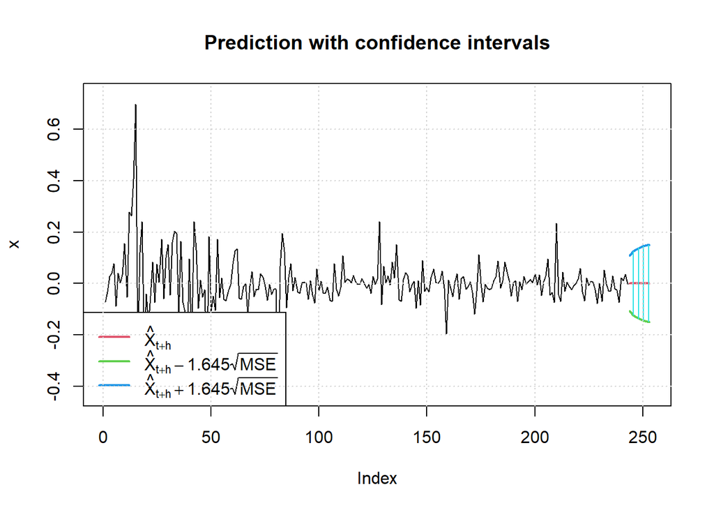

```r
fc_h <- predict(m1, n.ahead = 10, plot = TRUE, conf = 0.90, nx = length(ts_data))
```

# Jurnal 4

1. Ada satu langkah yang belum menurut saya yaitu Evaluasi model seperti menggunakan Mean Absolute Error (MAE), Mean Squared Error (MSE), atau Root Mean Squared Error (RMSE). dan kita bandingkan dengan performa model dengan baseline sederhana (misalnya rata-rata historis).

```r
predictions <- predict(m1, n.ahead = length(ts_data))$meanForecast

actuals <- ts_data

rmse <- sqrt(mean((actuals - predictions)^2))
print(paste("RMSE:", rmse))
```

```
## [1] "RMSE: 0.102691829380321"
```

```r
mape <- function(actual, forecast) {
  return(mean(abs((actual - predictions) / actual)) * 100)
}
mape_value <- mape(actuals, predictions)
print(paste("MAPE:", mape_value, "%"))
```

```
## [1] "MAPE: 103.233743262203 %"
```

#Simulasi Monte Carlo

```r
# Inisialisasi variabel untuk simulasi
data_return <- diff(log(data$Close))
sd_return <- sd(data_return)
omega <- mod_h3@fit$matcoef[1]
alpha_1 <- mod_h3@fit$matcoef[2]
beta_1 <- mod_h3@fit$matcoef[3]
garch_11 <- function(sd_data_prev, data_prev) {
sigma_t <- sqrt(omega + alpha_1 * data_prev^2 + beta_1 * sd_data_prev^2)
data_t <- sigma_t * rnorm(n = 1, mean = 0, sd = 1)
return(list(sigma_new = sigma_t, data_new = data_t))
}
hasil_simulasi <- matrix(0, 1000, 10) # Menyimpan data pada matriks
for (ukuran_simulasi in 1:1000) {
data_sim <- tail(data_return, n = 1)
sd_sim <- sd(data_return)
for (t in 244:253) {
garch_sim <- garch_11(sd_sim, tail(data_sim, n = 1))
sd_sim <- garch_sim$sigma_new
data_sim <- c(data_sim, garch_sim$data_new)
}
dummy <- tail(data_sim, n = 10)
hasil_simulasi[ukuran_simulasi, 1:10] <- dummy
}
```

```r
statistik <- data.frame(row.names = c("Rataan", "Stdev", "Median",
"Persentil90", "Persentil95"))
for (i in 1:10) {
statistik[1, i] <- mean(hasil_simulasi[1:1000, i])
statistik[2, i] <- sd(hasil_simulasi[1:1000, i])
statistik[3, i] <- median(hasil_simulasi[1:1000, i])
statistik[4, i] <- quantile(hasil_simulasi[1:1000, i], probs = 0.9)
statistik[5, i] <- quantile(hasil_simulasi[1:1000, i], probs = 0.95)
}
statistik
```

|  | V1 | V2 | V3 | V4 | V5 | V6 | V7 | V8 | V9 | V10 |
| --- | --- | --- | --- | --- | --- | --- | --- | --- | --- | --- |
| Rataan | -0.003624277 | -0.0003527677 | -0.0009343669 | -0.0020719825 | 0.007169576 | -0.0013236272 | 0.005883628 | -6.593842e-05 | -0.005490010 | -2.043785e-03 |
| Stdev | 0.088821666 | 0.0878580803 | 0.0878045024 | 0.0913254764 | 0.091940826 | 0.0894517473 | 0.097556224 | 9.122822e-02 | 0.092457969 | 9.191748e-02 |
| Median | -0.002534516 | 0.0002452097 | -0.0051166306 | 0.0002766074 | 0.008771015 | 0.0009287178 | 0.004385983 | 1.413305e-03 | -0.007934906 | 2.596295e-06 |
| Persentil90 | 0.108295564 | 0.1079796689 | 0.1104518320 | 0.1095674091 | 0.117092214 | 0.1082942650 | 0.121949744 | 1.095659e-01 | 0.110015896 | 1.046320e-01 |
| Persentil95 | 0.135195324 | 0.1387140061 | 0.1388891655 | 0.1402557969 | 0.151637329 | 0.1442736336 | 0.156716680 | 1.397195e-01 | 0.145522311 | 1.435705e-01 |

# Jurnal 6

$$C(t) = \Phi(d_1) \cdot S_t - \Phi(d_2) \cdot K \cdot \exp(-r(T - t))$$

dengan

$$\begin{align*}
d_1 &= \frac{\ln\left(\frac{S_t}{K}\right) + \left(r +
\frac{\sigma^2}{2}\right)(T - t)}{\sigma \sqrt{T - t}} \\
d_2 &= d_1 - \sigma \sqrt{T - t}
\end{align*}$$

di mana:

- $C(t)$ adalah harga opsi call pada waktu $t$.
- $\Phi(\cdot)$ adalah fungsi distribusi kumulatif normal baku.
- $S_t$ adalah harga Doge Coin pada waktu $t$.
- $K$ adalah Strike Price, dengan asumsi $K = 0.03$.
- $\sigma$ adalah volatilitas atau standar deviasi dari harga Doge Coin.
- $T$ adalah waktu tenor, dengan asumsi $T = 253$.
- $r$ adalah suku bunga tak berisiko, dengan asumsi $r = 1\%$.
- $d_1$ dan $d_2$ adalah parameter-parameter yang dihitung sesuai definisi di atas. ]

```r
# Fungsi untuk menghitung harga opsi call
  BlackScholesCall <- function(S_t, K, r, T, sigma,t) {
  d1 <- (log(S_t / K) + (r + sigma^2 / 2) * (T-t)) / (sigma * sqrt(T-t)/365.25)
  d2 <- d1 - sigma * sqrt(T-t/365.25)

  call_price <- pnorm(d1) * S_t - pnorm(d2) * K * exp(-r * (T-t)/365.25)

  return(call_price)
}
# Menentukan nilai variabel
t <- 1
S_t <- data$Close[1]  # Harga Doge Coin pada waktu t
K <- 0.03  # Harga kesepakatan (strike price)
r <- 0.01  # Tingkat bunga bebas risiko
T <- 244 : 253    # Waktu jatuh tempo opsi
sigma <- sd(data$Close) # Volatilitas
# Menghitung harga opsi call
call_price <- BlackScholesCall(S_t = S_t, K, r, T, sigma,t)
call_price
```

```
##  [1] 0.03218493 0.03218574 0.03218656 0.03218737 0.03218819 0.03218901
##  [7] 0.03218982 0.03219064 0.03219145 0.03219227
```

```r
pnorm(9.055544)
```

```
## [1] 1
```

# Jurnal Pratikum 5

# Eda

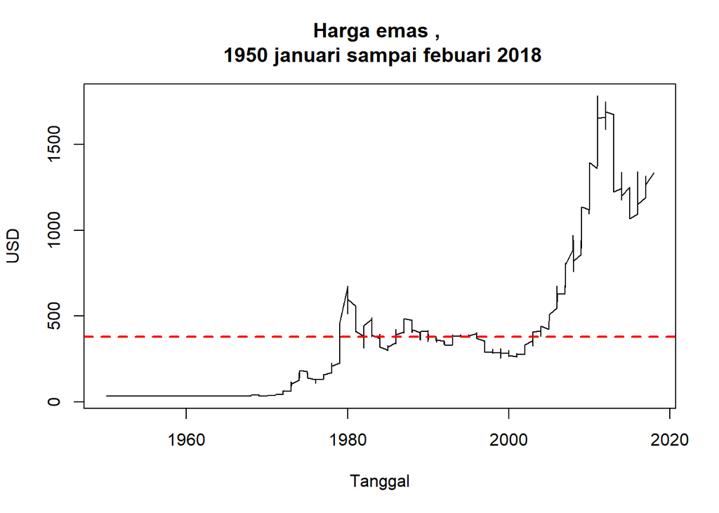

```r
library(readr)
data1 <- read_csv("Set Data Gold.csv", col_types = cols(date = col_date(format = "%d/%m/%Y")))
plot(data1$date, data1$price, type = "l", main = "Harga emas , \n 1950 januari sampai febuari 2018",
xlab = "Tanggal", ylab = "USD")
# Membuat garis rataan
abline(h = mean(data1$price), lwd = 2, lty = 2, col = "red")
```

```r
#View(data1)
summary(data1$price)
```

```
##    Min. 1st Qu.  Median    Mean 3rd Qu.    Max.
##   34.49   35.19  303.03  381.19  422.87 1780.65
```

```r
#fdr_bs = ts(data1$price,start = 1950-01-01, frequency = 4)
#x_grid = seq(1, length(data1$price), by=1/3)
#s_fdr_bs = splinefun(x=data1$date, y=fdr_bs, method="natural", ties = mean)
#new_s_fdr_bs = s_fdr_bs(x_grid)
```

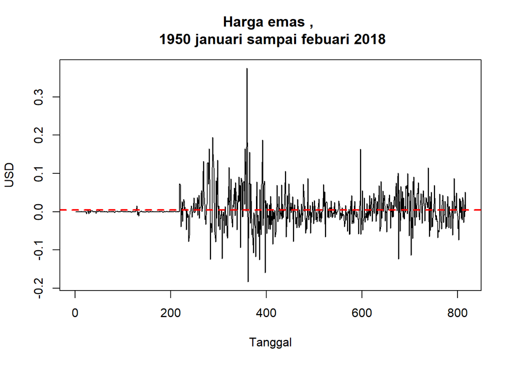

```r
ts_data1 <- ts(diff(log(data1$price)))
plot(ts_data1, type = "l", main = "Harga emas , \n 1950 januari sampai febuari 2018",
xlab = "Tanggal", ylab = "USD")
abline(h = mean(ts_data1), lwd = 2, lty = 2, col = "red")
```

# Data Deskriptifnya

```r
summary(data1$price)
```

```
##    Min. 1st Qu.  Median    Mean 3rd Qu.    Max.
##   34.49   35.19  303.03  381.19  422.87 1780.65
```

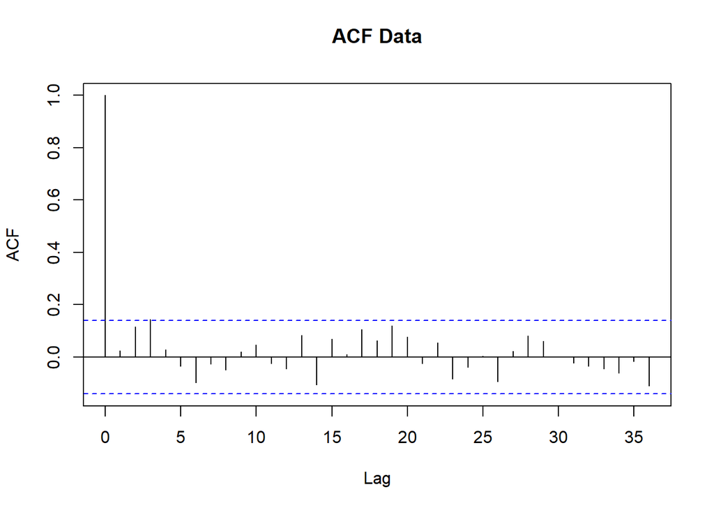

```r
ts_train_data1 <- ts_data1[1:(floor(0.8 * length(ts_data1)))]
ts_validation_data1 <- ts_data1[ceiling(0.8 * length(ts_data1)):length(ts_data1)]
acf(ts_train, main = "ACF Data", lag.max = 36)
```

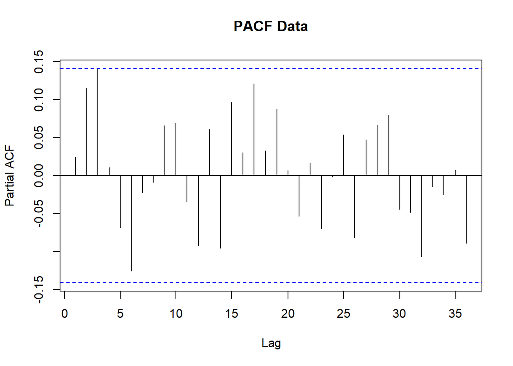

```r
pacf(ts_train, main = "PACF Data", lag.max = 36)
```

# Lakukan Forecasting Pada data emas

```r
mod_emas <- auto.arima(ts_data1, max.q = 0, allowmean = TRUE, allowdrift = TRUE,
method = "ML")
fc <- forecast(ts_data1, model = mod_emas, h = 10)
summary(mod_emas)
```

```
## Series: ts_data1
## ARIMA(3,0,0) with non-zero mean
##
## Coefficients:
##          ar1      ar2     ar3    mean
##       0.3253  -0.1504  0.0768  0.0045
## s.e.  0.0349   0.0363  0.0349  0.0018
##
## sigma^2 = 0.001542:  log likelihood = 1487.48
## AIC=-2964.97   AICc=-2964.9   BIC=-2941.44
##
## Training set error measures:
##                         ME      RMSE        MAE  MPE MAPE     MASE
## Training set -3.924408e-06 0.0391762 0.02456852 -Inf  Inf 0.798372
##                       ACF1
## Training set -0.0005451875
```

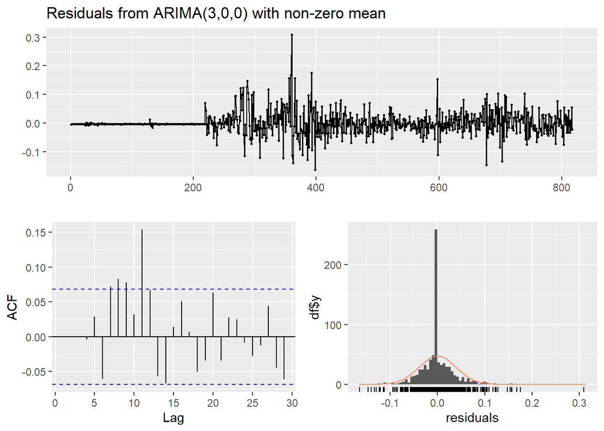

```
##
##  Ljung-Box test
##
## data:  Residuals from ARIMA(3,0,0) with non-zero mean
## Q* = 19.687, df = 7, p-value = 0.006286
##
## Model df: 3.   Total lags used: 10
```

```r
checkresiduals(mod_emas)
```

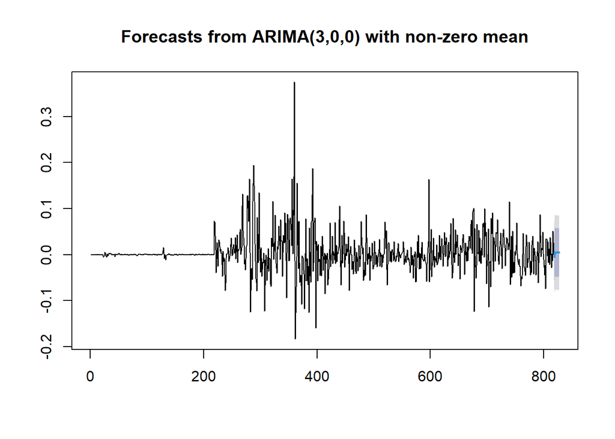

```r
plot(fc)
```

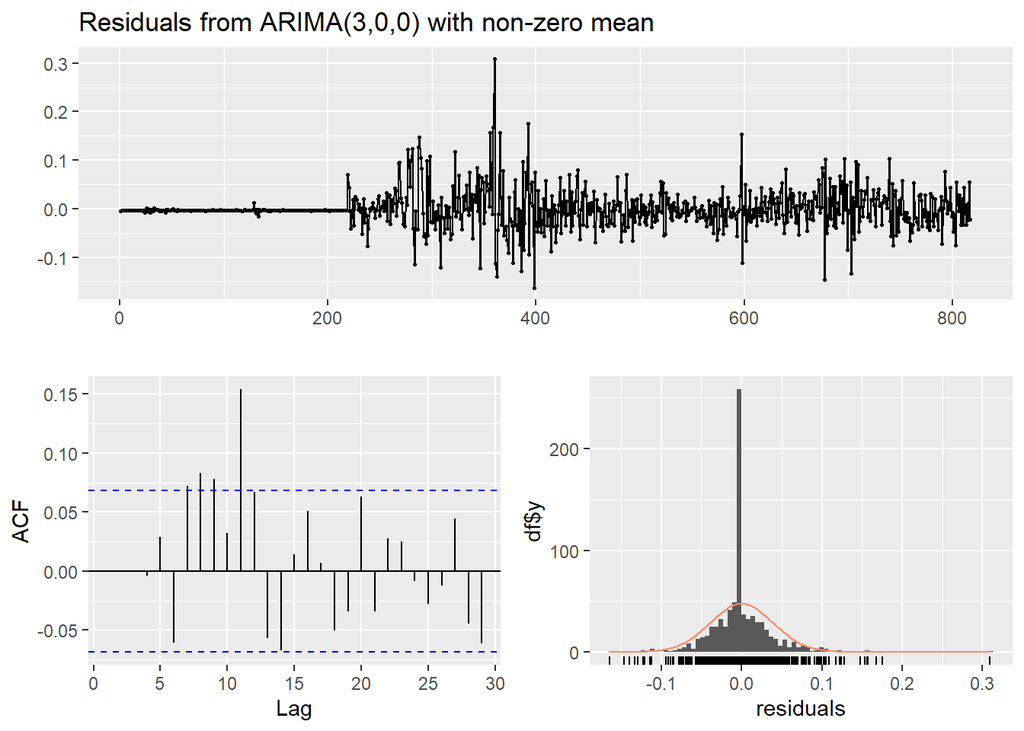

```
##
##  Ljung-Box test
##
## data:  Residuals from ARIMA(3,0,0) with non-zero mean
## Q* = 19.687, df = 7, p-value = 0.006286
##
## Model df: 3.   Total lags used: 10
```

```r
checkresiduals(mod_emas)
```

# Model Heteroskedastis

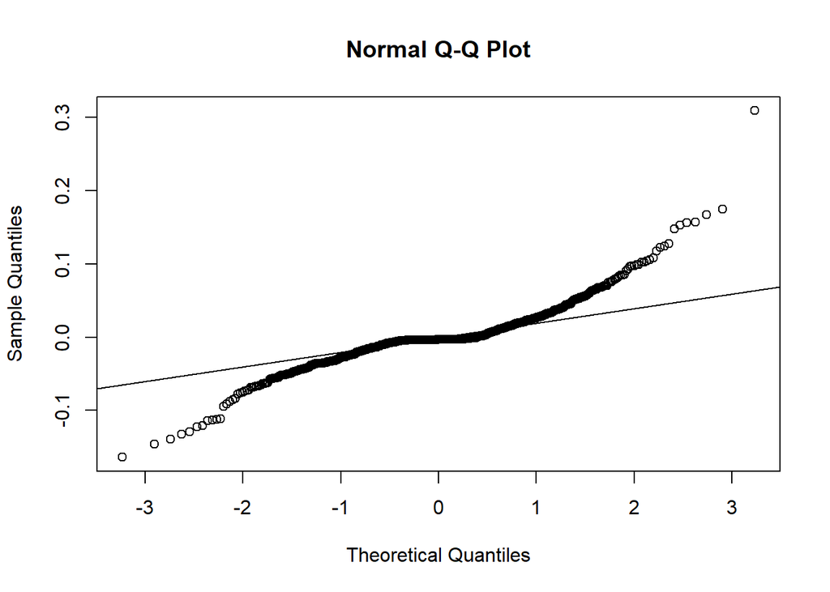

```r
residual_emas <- residuals(mod_emas, standardize = T)
# QQ Plot
qqnorm(residual_emas)
qqline(residual_emas)
```

```r
# Uji Anderson-Darling
ad.test(residual_emas)
```

```
##
##  Anderson-Darling normality test
##
## data:  residual_emas
## A = 31.11, p-value < 2.2e-16
```

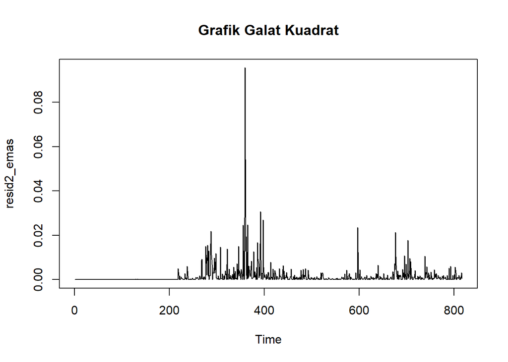

```r
resid2_emas <- residual_emas^2
plot(resid2_emas, main = "Grafik Galat Kuadrat", type = "l")
```

```r
Box.test(resid2_emas, lag = 12)
```

```
##
##  Box-Pierce test
##
## data:  resid2_emas
## X-squared = 272.47, df = 12, p-value < 2.2e-16
```

```r
ArchTest(residual_emas)
```

```
##
##  ARCH LM-test; Null hypothesis: no ARCH effects
##
## data:  residual_emas
## Chi-squared = 118.95, df = 12, p-value < 2.2e-16
```

## Dapat dilihat pada uji arch dan box-pierce , pada uji arch kita menolak hipotesis 0 brati adanya efek arch pada model harga emas yang kita uji dan uji tes box - pierce kita menolak hipotesis 0 yaitu brati ada kemungkinan autokorelasi yang signifikan

# Penentuan Model

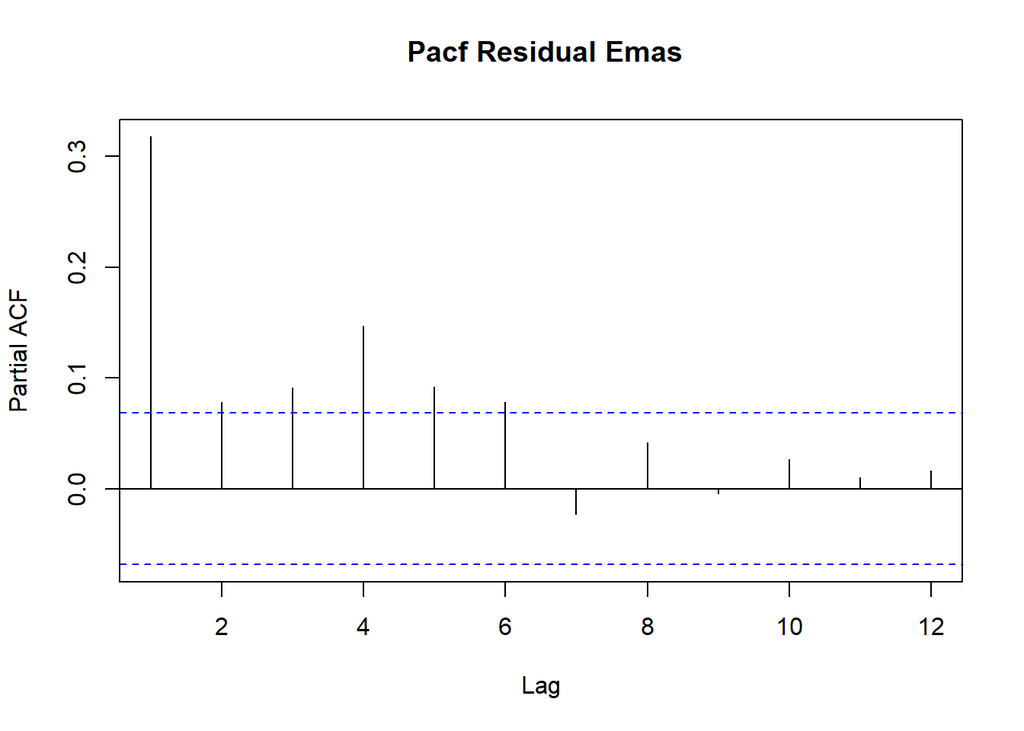

```r
pacf(resid2_emas,main = " Pacf Residual Emas",lag.max = 12)
```

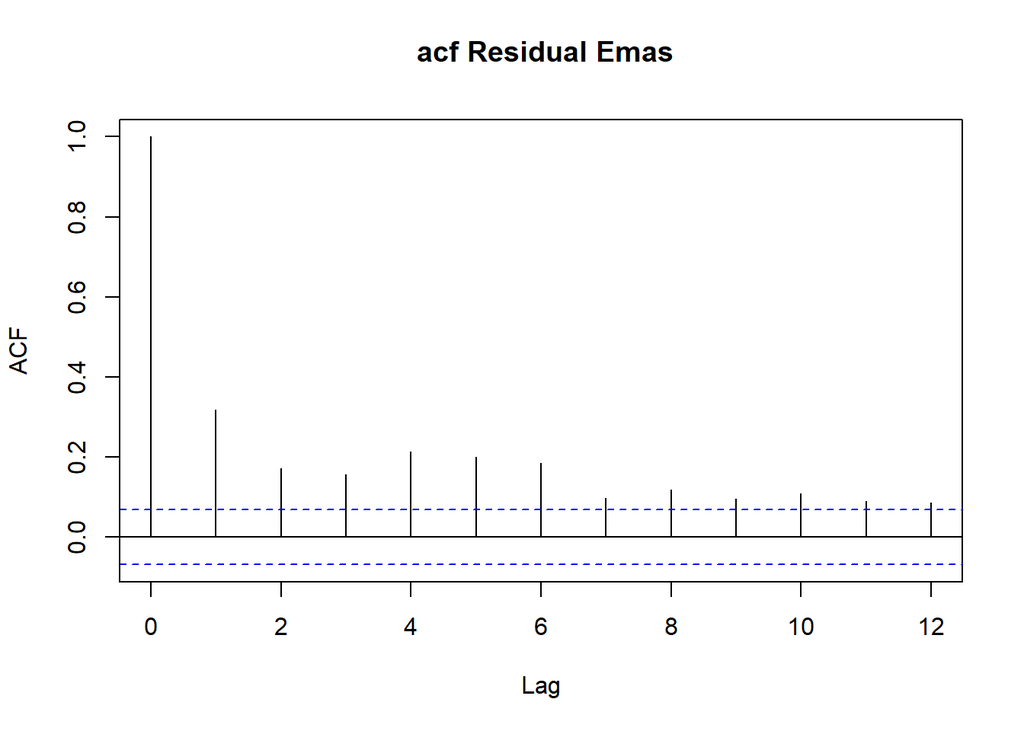

```r
acf(resid2_emas,main = " acf Residual Emas",lag.max = 12)
```

## Dapat dilihat dari grafik ACF dan PACFnya Dari grafik diperoleh model yang cocok adalah : 1. GARCH(4,1) 2. GARCH(4,0) 3. GARCH(1,1)

# Buat model Garch

```r
mod_h1_emas <- garchFit(residual ~ garch(4, 0), data = residual, trace = F,
include.mean = F)
mod_h2_emas <- garchFit(residual ~ garch(4,1 ), data = residual, trace = F,
include.mean = F)
mod_h3_emas <- garchFit(residual ~ garch(1, 1), data = residual, trace = F,
include.mean = F)

summary(mod_h1_emas)
```

```
##
## Title:
##  GARCH Modelling
##
## Call:
##  garchFit(formula = residual ~ garch(4, 0), data = residual, include.mean = F,
##     trace = F)
##
## Mean and Variance Equation:
##  data ~ garch(4, 0)
## <environment: 0x000001c003433c20>
##  [data = residual]
##
## Conditional Distribution:
##  norm
##
## Coefficient(s):
##      omega      alpha1      alpha2      alpha3      alpha4
## 0.00440755  0.25674046  0.23731243  0.00077167  0.02219222
##
## Std. Errors:
##  based on Hessian
##
## Error Analysis:
##         Estimate  Std. Error  t value Pr(>|t|)
## omega  0.0044076   0.0005732    7.690 1.49e-14 ***
## alpha1 0.2567405   0.1077819    2.382   0.0172 *
## alpha2 0.2373124   0.1195939    1.984   0.0472 *
## alpha3 0.0007717   0.0475915    0.016   0.9871
## alpha4 0.0221922   0.0557192    0.398   0.6904
## ---
## Signif. codes:  0 '***' 0.001 '**' 0.01 '*' 0.05 '.' 0.1 ' ' 1
##
## Log Likelihood:
##  254.8119    normalized:  1.048609
##
## Description:
##  Sat May 18 07:01:46 2024 by user: Admin
##
##
## Standardised Residuals Tests:
##                                    Statistic      p-Value
##  Jarque-Bera Test   R    Chi^2  1082.9275672 0.000000e+00
##  Shapiro-Wilk Test  R    W         0.8692057 1.453995e-13
##  Ljung-Box Test     R    Q(10)     7.3628855 6.907994e-01
##  Ljung-Box Test     R    Q(15)    10.4797648 7.885264e-01
##  Ljung-Box Test     R    Q(20)    16.9173260 6.583353e-01
##  Ljung-Box Test     R^2  Q(10)     0.9198940 9.998828e-01
##  Ljung-Box Test     R^2  Q(15)     2.1257683 9.999556e-01
##  Ljung-Box Test     R^2  Q(20)     2.5855044 9.999989e-01
##  LM Arch Test       R    TR^2      1.0513199 9.999813e-01
##
## Information Criterion Statistics:
##       AIC       BIC       SIC      HQIC
## -2.056065 -1.984192 -2.056890 -2.027115
```

```r
summary(mod_h2_emas)
```

```
##
## Title:
##  GARCH Modelling
##
## Call:
##  garchFit(formula = residual ~ garch(4, 1), data = residual, include.mean = F,
##     trace = F)
##
## Mean and Variance Equation:
##  data ~ garch(4, 1)
## <environment: 0x000001c0069f12a8>
##  [data = residual]
##
## Conditional Distribution:
##  norm
##
## Coefficient(s):
##      omega      alpha1      alpha2      alpha3      alpha4       beta1
## 0.00163707  0.23244166  0.00000001  0.00000001  0.00000001  0.58493122
##
## Std. Errors:
##  based on Hessian
##
## Error Analysis:
##         Estimate  Std. Error  t value Pr(>|t|)
## omega  1.637e-03         NaN      NaN      NaN
## alpha1 2.324e-01   1.680e-01    1.384    0.166
## alpha2 1.000e-08         NaN      NaN      NaN
## alpha3 1.000e-08   3.152e-01    0.000    1.000
## alpha4 1.000e-08   2.843e-01    0.000    1.000
## beta1  5.849e-01         NaN      NaN      NaN
##
## Log Likelihood:
##  255.1992    normalized:  1.050203
##
## Description:
##  Sat May 18 07:01:46 2024 by user: Admin
##
##
## Standardised Residuals Tests:
##                                    Statistic      p-Value
##  Jarque-Bera Test   R    Chi^2  1170.2138885 0.000000e+00
##  Shapiro-Wilk Test  R    W         0.8673926 1.145821e-13
##  Ljung-Box Test     R    Q(10)     6.6134236 7.613663e-01
##  Ljung-Box Test     R    Q(15)     8.7551850 8.899661e-01
##  Ljung-Box Test     R    Q(20)    15.3441374 7.563890e-01
##  Ljung-Box Test     R^2  Q(10)     0.8903664 9.998992e-01
##  Ljung-Box Test     R^2  Q(15)     1.8285805 9.999837e-01
##  Ljung-Box Test     R^2  Q(20)     2.3564548 9.999995e-01
##  LM Arch Test       R    TR^2      0.9822299 9.999872e-01
##
## Information Criterion Statistics:
##       AIC       BIC       SIC      HQIC
## -2.051022 -1.964774 -2.052203 -2.016282
```

```r
summary(mod_h3_emas)
```

```
##
## Title:
##  GARCH Modelling
##
## Call:
##  garchFit(formula = residual ~ garch(1, 1), data = residual, include.mean = F,
##     trace = F)
##
## Mean and Variance Equation:
##  data ~ garch(1, 1)
## <environment: 0x000001c0081da458>
##  [data = residual]
##
## Conditional Distribution:
##  norm
##
## Coefficient(s):
##     omega     alpha1      beta1
## 0.0016872  0.2396254  0.5734003
##
## Std. Errors:
##  based on Hessian
##
## Error Analysis:
##         Estimate  Std. Error  t value Pr(>|t|)
## omega  0.0016872   0.0005791    2.913  0.00358 **
## alpha1 0.2396254   0.0735329    3.259  0.00112 **
## beta1  0.5734003   0.1077911    5.320 1.04e-07 ***
## ---
## Signif. codes:  0 '***' 0.001 '**' 0.01 '*' 0.05 '.' 0.1 ' ' 1
##
## Log Likelihood:
##  255.6761    normalized:  1.052165
##
## Description:
##  Sat May 18 07:01:46 2024 by user: Admin
##
##
## Standardised Residuals Tests:
##                                    Statistic      p-Value
##  Jarque-Bera Test   R    Chi^2  1154.1409371 0.000000e+00
##  Shapiro-Wilk Test  R    W         0.8685548 1.334475e-13
##  Ljung-Box Test     R    Q(10)     6.7058092 7.528957e-01
##  Ljung-Box Test     R    Q(15)     8.9137755 8.819825e-01
##  Ljung-Box Test     R    Q(20)    15.4470797 7.502798e-01
##  Ljung-Box Test     R^2  Q(10)     0.8316636 9.999266e-01
##  Ljung-Box Test     R^2  Q(15)     1.7697608 9.999869e-01
##  Ljung-Box Test     R^2  Q(20)     2.2832842 9.999996e-01
##  LM Arch Test       R    TR^2      0.9397625 9.999900e-01
##
## Information Criterion Statistics:
##       AIC       BIC       SIC      HQIC
## -2.079639 -2.036515 -2.079939 -2.062269
```

# Forecast

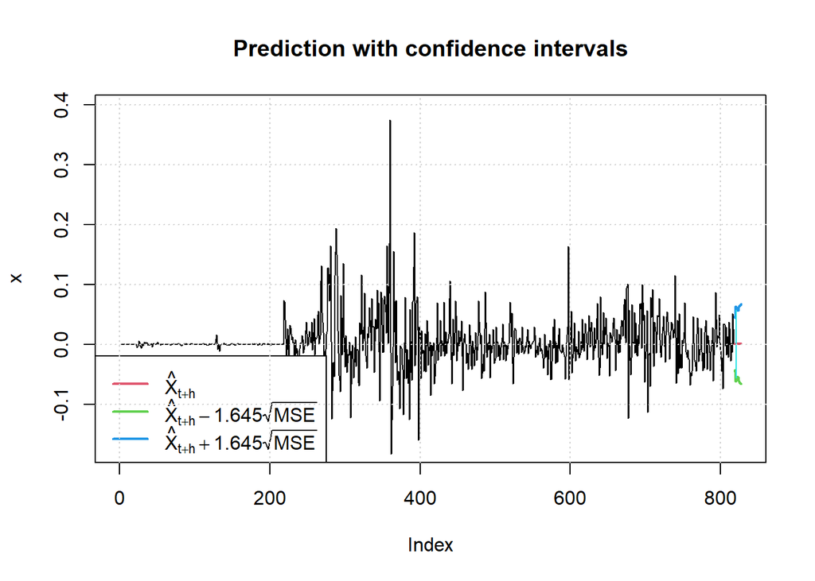

```r
m1_emas <- garchFit(ts_data1 ~ arma(0, 0) + garch(4, 1), data = ts_data1,
trace = F)
fc_h_emas <- predict(m1_emas, n.ahead = 10, plot = TRUE, conf = 0.90, nx = length(ts_data1))
```

# Akan Mencoba menghitung hasil call price nya dengan BlackSholesCall

```r
# Fungsi untuk menghitung harga opsi call
  BlackScholesCall <- function(S_t, K, r, T, sigma,t) {
  d1 <- (log(S_t / K) + (r + sigma^2 / 2) * (T-t)) / (sigma * sqrt(T-t)/365.25)
  d2 <- d1 - sigma * sqrt(T-t/365.25)

  call_price <- pnorm(d1) * S_t - pnorm(d2) * K * exp(-r * (T-t)/365.25)

  return(call_price)
}
# Menentukan nilai variabel
t <- 1
S_t <- data1$price[1]  # Harga Doge Coin pada waktu t
K <- 0.03  # Harga kesepakatan (strike price)
r <- 0.01  # Tingkat bunga bebas risiko
T <- 244 : 253    # Waktu jatuh tempo opsi
sigma <- sd(data$Close) # Volatilitas
# Menghitung harga opsi call
call_price <- BlackScholesCall(S_t = S_t, K, r, T, sigma,t)
call_price
```

```
##  [1] 34.70020 34.70020 34.70020 34.70020 34.70020 34.70020 34.70020 34.70020
##  [9] 34.70021 34.70021
```

```r
# ARIMA(3,0,0)-GARCH(1,1)
#model2_fdr_bs <- ugarchspec(variance.model =
# list(model="sGARCH", garchOrder=c(4,0)),
# mean.model = list(armaOrder=c(1, 1),
# arfima = T), # using arfima model
# fixed.pars=list(arfima = 0), # If you want to fix d
# distribution.model = "norm")

#val2_fdr_bs_fit = ugarchfit(model2_fdr_bs, ts_train_data1, solver = "hybrid")
#val2_fdr_bs_pred = ugarchforecast(val2_fdr_bs_fit,
# n.ahead = length(ts_validation_data1))

#actual = as.vector(ts_validation_data1)
#ape1_validation <- abs((as.vector(val2_fdr_bs_pred@forecast[["seriesFor"]]) - actual)/actual)
#(mape1_validation <- mean(ape1_validation))
```

```r
#spec_fdr_bs = getspec(val2_fdr_bs_fit)
#(setfixed(spec_fdr_bs) = as.list(coef(val2_fdr_bs_fit)))



#fdr_bs_pred = ugarchforecast(spec_fdr_bs, data=ts(data1$price, n.ahead = 12)
# Selang kepercayaan 95%
#upper_fdr_bs = fitted(val2_fdr_bs_fit)+1.96*val2_fdr_bs_pred@forecast[["sigmaFor"]]
#lower_fdr_bs = fitted(val2_fdr_bs_fit)-1.96*val2_fdr_bs_pred@forecast[["sigmaFor"]]
#plot(ts(new_s_fdr_bs, start = c(2012,3),frequency = 12), type = 'l', col = 'blue',xlim = c(20
#12, 2025),
# main="Plot Hasil Forecast Sesuatu", ylab="Nilai Sesuatu", xlab="Waktu")
#polygon(c(time(ts(upper_fdr_bs, start = 2024, frequency = 12)),
# rev(time(ts(upper_fdr_bs, start = 2024, frequency = 12)))), c(upper_fdr_bs, rev(low
#er_fdr_bs)), col = rgb(1, 1, 0, 0.3), border = NA) # Shaded confidence interval
##l = 'red')
```

#Simulasi Monte Carlo pada data emas

```r
# Inisialisasi variabel untuk simulasi
data_return1 <- diff(log(data1$price))
sd_return <- sd(data_return1)
omega <- mod_h1_emas@fit$matcoef[1]
alpha_1 <- mod_h1_emas@fit$matcoef[2]
beta_1 <- mod_h1_emas@fit$matcoef[3]
garch_41 <- function(sd_data_prev, data_prev) {
sigma_t <- sqrt(omega + alpha_1 * data_prev^2 + beta_1 * sd_data_prev^2)
data_t <- sigma_t * rnorm(n = 1, mean = 0, sd = 1)
return(list(sigma_new = sigma_t, data_new = data_t))
}
hasil_simulasi1 <- matrix(0, 1000, 10) # Menyimpan data pada matriks
for (ukuran_simulasi1 in 1:1000) {
data_sim1 <- tail(data_return1, n = 1)
sd_sim <- sd(data_return1)
for (t in 244:253) {
garch_sim1 <- garch_41(sd_sim, tail(data_sim, n = 1))
sd_sim1 <- garch_sim1$sigma_new
data_sim1 <- c(data_sim, garch_sim$data_new)
}
dummy1 <- tail(data_sim, n = 10)
hasil_simulasi1[ukuran_simulasi, 1:10] <- dummy1
}
```

```r
statistik1 <- data.frame(row.names = c("Rataan", "Stdev", "Median",
"Persentil90", "Persentil95"))
for (i in 1:10) {
statistik[1, i] <- mean(hasil_simulasi1[1:100, i])
statistik[2, i] <- sd(hasil_simulasi1[1:100, i])
statistik[3, i] <- median(hasil_simulasi1[1:100, i])
statistik[4, i] <- quantile(hasil_simulasi1[1:100, i], probs = 0.9)
statistik[5, i] <- quantile(hasil_simulasi1[1:100, i], probs = 0.95)
}
statistik1
```

[output not shown]